# a3_task3_chelsie_mcwhorter

Chelsie McWhorter

10/26/2021

## Part 1: Introduction & Exploring Urchin Data in R

Introduction: Using a data file on sea urchins provided by the [Santa Barbara Coastal LTER](https://sbclter.msi.ucsb.edu/data/catalog/package/?package=knb-lter-sbc.26), I’ll review the data to get an idea of what is present. Then I’ll follow the prompts to visualize it, compile descriptive statistics and summarize what I’ve found.

Data citation: Reed, D, R. Miller. 2021. SBC LTER: Reef: Long-term experiment: Kelp removal: Urchin size frequency distribution ver 21. Environmental Data Initiative. https://doi.org/10.6073/pasta/fd564dddfe7b77fe9e4bd8417f166057. Accessed 2021-10-28.

**Reading in the data:**

```r
urchins <- read_csv(here("data" , "urchins.csv")) %>% #reading in the data file
  clean_names() # change headers to lower snakecase

#viewing the data via console `view(urchins)` to get an overview of what it contains.
```

### Section 1: Size comparisons of purple and red urchins

#### *Sub-section i:* Data visualization.

Below I’ll create a histogram to see how the data are distributed.

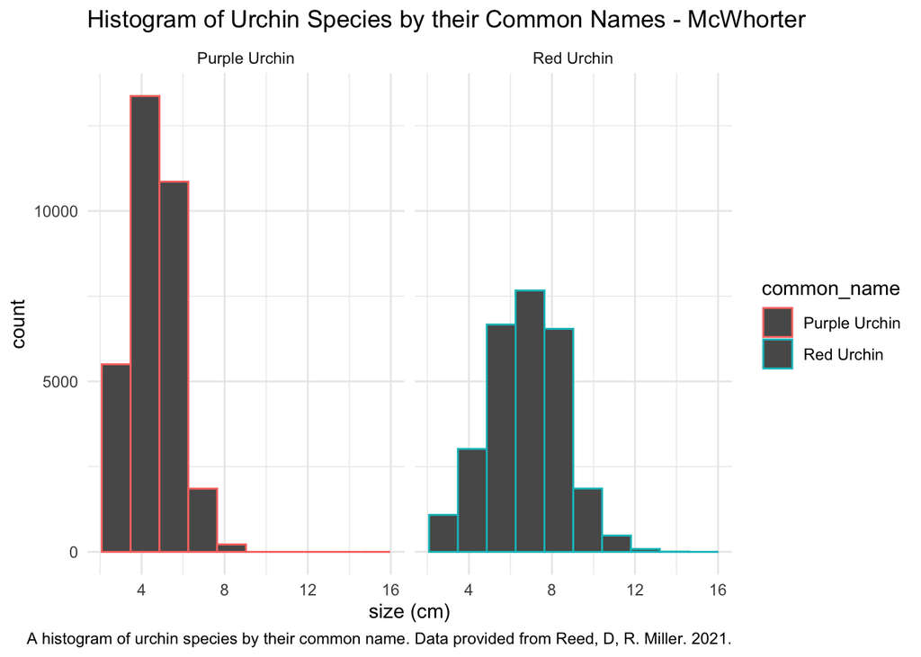

```r
ggplot(data = urchins, aes(x = size)) +
  geom_histogram(aes(color = common_name), bins = 10) + #I spent probably too much time trying to figure out how to make the 'purple urchin' plot fill with purple, and the "red urchin' plot fill with red, but couldn't figure it out.
  facet_wrap(~ common_name) +
  theme_minimal() +
  labs(x = "size (cm)", y = "count",
       title = "Histogram of Urchin Species by their Common Names - McWhorter",
       caption = "A histogram of urchin species by their common name. Data provided from Reed, D, R. Miller. 2021."
       )
```

#### *Sub-section ii:* Descripitve statistics table:

Now I’ll compile some descriptive statistics for the urchin data.

```r
urchin_stats <- urchins %>%
  group_by(common_name) %>%
  summarize(mean_size_cm = mean(size),
            median_size_cm = median(size),
            sd_size = sd(size),
            samplesize = n())

#Now I'll try to make it nicer looking via 'kableextra':

urchin_stats %>%
  kable(col.names = c("Common Name",
                      "Mean Size (cm)",
                      "Median Size (cm)",
                      "Standard Deviation",
                      "Sample Size (n)")) %>%
  kable_styling(position = "center", full_width = FALSE)
```

| Common Name | Mean Size (cm) | Median Size (cm) | Standard Deviation | Sample Size (n) |
| --- | --- | --- | --- | --- |
| Purple Urchin | 4.469797 | 4.5 | 1.175264 | 31805 |
| Red Urchin | 6.776489 | 7.0 | 1.891343 | 27408 |

### Section 2: Exploring purple urchin counts by site and year.

#### *Subsection i:* Creating a subset of purple urchins with the following condiditons:

- Filter to only include observations for purple urchins
- Convert the date to class “Date”
- Create a new column that only contains the year
- Create a new column called site_full that contains the full name (not abbreviation) for each of the ! sites

```r
purple_urchins <- urchins %>%
  filter(common_name == "Purple Urchin") %>%
  mutate(date_correct = mdy(date)) %>%  #convert 'date' column to class(date) and check in console "class(purple_urchins$date_correct)"
  mutate(year = year(date_correct)) %>%  # pull out just the year
  mutate(site_full = case_when(
    site %in% "NAPL" ~ "Naples Reef",
    site %in% "AQUE" ~ "Arroyo Quemado Reef",
    site %in% "CARP" ~ "Carpinteria Reef",
    site %in% "MOHK" ~ "Mohawk Reef",
    site %in% "IVEE" ~ "Isla Vista Reef"
  ))
  #confirm the sites are present by running unique(purple_urchins$site_full) in the console & of course view the data via view(purple_urchins) in the console.
```

#### *Subsection ii:* Total number of purple urchins observed by site & year.

In this section I’ll take a look at purple urchins with consideration or both the site and the year.

```r
purple_urchins_counts <- purple_urchins %>%
  group_by(site_full, year) %>%
  summarise(count = n())
#confirm via console check of both view(purple_urchins_counts) and unique(purple_urchins_counts$site_full) &  unique(purple_urchins_counts$year)
```

#### *Subsection iii:* Make a graph of purple urchins recorded at each site over time.

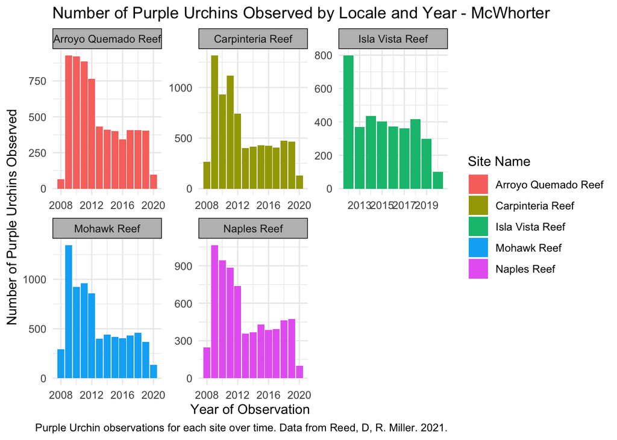

```r
ggplot(data = purple_urchins_counts, aes(x = year, y = count)) +
  geom_bar(aes(fill = site_full), stat ='identity') +
  theme_minimal() +
  theme(strip.background = element_rect(fill = 'gray')) +
  facet_wrap(~site_full, scales = 'free') +
  labs(x = "Year of Observation",
       y = "Number of Purple Urchins Observed",
       title = "Number of Purple Urchins Observed by Locale and Year - McWhorter",
       fill = "Site Name",
       caption = "Purple Urchin observations for each site over time. Data from Reed, D, R. Miller. 2021.")
```

#### *Subsection iv:* Analysis of the graph.

**Question:** *What would you have to take into account to determine whether the changes in counts by year are reflective of actual changes in urchin population?*

- Total population of urchins beyond our sample data collected.

**Question:** *What else could explain the changes in number of purple urchins observed?*

Ideas:*

- Equipment calibration and use on data collection days;
- Number of research assistants / personnel available to collect data from equipment / instruments;
- Clarity of the water on data collection days

*Disclaimer: as primarily a human geographer, I’m not super familiar with how these types of data are collected, so I apologize if my responses are ignorant.

### Assignment 3, Task 3 is complete.